### Author : ABDELMONEM ELMONGY

### Data : 09/2023

# Project : Sales Data Analysis

Sales of products for 12 months period.

## About Dataset:

The dataset consists of 11 columns, each column representing an attribute of purchase on a product -

```
Order ID - A unique ID for each order placed on a product
Product - Item that is purchased
Quantity Ordered - Describes how many of that products are ordered
Price Each - Price of a unit of that product
Order Date - Date on which the order is placed
Purchase Address - Address to where the order is shipped
Month, Sales, City, Hour - Extra attributes formed from the above.
```

### Sources:

#### Acknowledgements

Dataset is downloaded and compiled from KeithGalli's GitHub repository on Pandas Data Science Tasks. You find and access the repository [here](https://github.com/KeithGalli/Pandas-Data-Science-Tasks)

#### Inspiration

A Dataset to practice basic EDA and Cleaning.

[Source from kaggle](https://www.kaggle.com/datasets/beekiran/sales-data-analysis)

- Introduction
- Data Wrangling
- Exploratory Data Analysis

## Introduction

#### Your task is to:

01 - Gathering data.

02 - Assessing data.

03 - Cleaning data.

04 - Storing data.

05 - Analyzing, and visualizing data.

06 - Reporting

```
    your data wrangling efforts
    your data analyses and visualizations
```

```python
import numpy as np
import pandas as pd
import seaborn as sns
import matplotlib.pyplot as plt
from matplotlib import colors
from matplotlib.ticker import PercentFormatter

%matplotlib inline

import os
```

## Data Wrangling

> **Tip**: In this section of the report, you will load in the data, check for cleanliness, and then trim and clean your dataset for analysis. Make sure that you **document your data cleaning steps in mark-down cells precisely and justify your cleaning decisions.**

## Data Wrangling which include :

Gathering Data

Assessing Data

Cleaning Data

## Gathering Data

we aqucistion data from dataset like : csv file in our example

```python
# Load your data and print out a few lines. Perform operations to inspect data
# types and look for instances of missing or possibly errant data.
sales = pd.read_csv('data/Sales Data.csv')
```

we use head() or tail() function to display a sample of data

```python
sales.head()
```

|  | Unnamed: 0 | Order ID | Product | Quantity Ordered | Price Each | Order Date | Purchase Address | Month | Sales | City | Hour |
| --- | --- | --- | --- | --- | --- | --- | --- | --- | --- | --- | --- |
| 0 | 0 | 295665 | Macbook Pro Laptop | 1 | 1700.00 | 2019-12-30 00:01:00 | 136 Church St, New York City, NY 10001 | 12 | 1700.00 | New York City | 0 |
| 1 | 1 | 295666 | LG Washing Machine | 1 | 600.00 | 2019-12-29 07:03:00 | 562 2nd St, New York City, NY 10001 | 12 | 600.00 | New York City | 7 |
| 2 | 2 | 295667 | USB-C Charging Cable | 1 | 11.95 | 2019-12-12 18:21:00 | 277 Main St, New York City, NY 10001 | 12 | 11.95 | New York City | 18 |
| 3 | 3 | 295668 | 27in FHD Monitor | 1 | 149.99 | 2019-12-22 15:13:00 | 410 6th St, San Francisco, CA 94016 | 12 | 149.99 | San Francisco | 15 |
| 4 | 4 | 295669 | USB-C Charging Cable | 1 | 11.95 | 2019-12-18 12:38:00 | 43 Hill St, Atlanta, GA 30301 | 12 | 11.95 | Atlanta | 12 |

```python
sales.tail()
```

|  | Unnamed: 0 | Order ID | Product | Quantity Ordered | Price Each | Order Date | Purchase Address | Month | Sales | City | Hour |
| --- | --- | --- | --- | --- | --- | --- | --- | --- | --- | --- | --- |
| 185945 | 13617 | 222905 | AAA Batteries (4-pack) | 1 | 2.99 | 2019-06-07 19:02:00 | 795 Pine St, Boston, MA 02215 | 6 | 2.99 | Boston | 19 |
| 185946 | 13618 | 222906 | 27in FHD Monitor | 1 | 149.99 | 2019-06-01 19:29:00 | 495 North St, New York City, NY 10001 | 6 | 149.99 | New York City | 19 |
| 185947 | 13619 | 222907 | USB-C Charging Cable | 1 | 11.95 | 2019-06-22 18:57:00 | 319 Ridge St, San Francisco, CA 94016 | 6 | 11.95 | San Francisco | 18 |
| 185948 | 13620 | 222908 | USB-C Charging Cable | 1 | 11.95 | 2019-06-26 18:35:00 | 916 Main St, San Francisco, CA 94016 | 6 | 11.95 | San Francisco | 18 |
| 185949 | 13621 | 222909 | AAA Batteries (4-pack) | 1 | 2.99 | 2019-06-25 14:33:00 | 209 11th St, Atlanta, GA 30301 | 6 | 2.99 | Atlanta | 14 |

## Assessing Data

We assessing our data using some function like : shape , ndim , dtypes , size , info() , nunique() , isnull()

```python
# return number of columns and number of row
sales.shape
```

```
(185950, 11)
```

the shape function get number of rows and number of columns in tuple

```python
#return number of dimensions of data
sales.ndim
```

```
2
```

size function show us the result of multiplication of number of rows and number of columns

```python
# return size of Dataset which is a multiplication of number of rows and number of columns
sales.size
```

```
2045450
```

dtypes show us data type of each column (features)

```python
sales.head(1)
```

|  | Unnamed: 0 | Order ID | Product | Quantity Ordered | Price Each | Order Date | Purchase Address | Month | Sales | City | Hour |
| --- | --- | --- | --- | --- | --- | --- | --- | --- | --- | --- | --- |
| 0 | 0 | 295665 | Macbook Pro Laptop | 1 | 1700.0 | 2019-12-30 00:01:00 | 136 Church St, New York City, NY 10001 | 12 | 1700.0 | New York City | 0 |

```python
#return types of each column
sales.dtypes
```

```
Unnamed: 0            int64
Order ID              int64
Product              object
Quantity Ordered      int64
Price Each          float64
Order Date           object
Purchase Address     object
Month                 int64
Sales               float64
City                 object
Hour                  int64
dtype: object
```

info() function show us number of non_null_value in each column and datatype

it has two features(no of non_null_value,datatype)

```python
#return number of non-null-value and datatype of each column
sales.info()
```

```
<class 'pandas.core.frame.DataFrame'>
RangeIndex: 185950 entries, 0 to 185949
Data columns (total 11 columns):
 #   Column            Non-Null Count   Dtype
---  ------            --------------   -----
 0   Unnamed: 0        185950 non-null  int64
 1   Order ID          185950 non-null  int64
 2   Product           185950 non-null  object
 3   Quantity Ordered  185950 non-null  int64
 4   Price Each        185950 non-null  float64
 5   Order Date        185950 non-null  object
 6   Purchase Address  185950 non-null  object
 7   Month             185950 non-null  int64
 8   Sales             185950 non-null  float64
 9   City              185950 non-null  object
 10  Hour              185950 non-null  int64
dtypes: float64(2), int64(5), object(4)
memory usage: 15.6+ MB
```

nunique() show us number of unique values in each column

```python
#return number of unique value
sales.nunique()
```

```
Unnamed: 0           25093
Order ID            178437
Product                 19
Quantity Ordered         9
Price Each              17
Order Date          142395
Purchase Address    140787
Month                   12
Sales                   53
City                     9
Hour                    24
dtype: int64
```

```python
City_value_counts = sales.City.value_counts()
City_value_counts
```

```
 San Francisco    44732
 Los Angeles      29605
 New York City    24876
 Boston           19934
 Atlanta          14881
 Dallas           14820
 Seattle          14732
 Portland         12465
 Austin            9905
Name: City, dtype: int64
```

```python
Product_value_counts = sales.Product.value_counts()
Product_value_counts
```

```
USB-C Charging Cable          21903
Lightning Charging Cable      21658
AAA Batteries (4-pack)        20641
AA Batteries (4-pack)         20577
Wired Headphones              18882
Apple Airpods Headphones      15549
Bose SoundSport Headphones    13325
27in FHD Monitor               7507
iPhone                         6842
27in 4K Gaming Monitor         6230
34in Ultrawide Monitor         6181
Google Phone                   5525
Flatscreen TV                  4800
Macbook Pro Laptop             4724
ThinkPad Laptop                4128
20in Monitor                   4101
Vareebadd Phone                2065
LG Washing Machine              666
LG Dryer                        646
Name: Product, dtype: int64
```

```python
Month_value_counts = sales.Month.value_counts()
Month_value_counts
```

```
12    24984
10    20282
4     18279
11    17573
5     16566
3     15153
7     14293
6     13554
2     11975
8     11961
9     11621
1      9709
Name: Month, dtype: int64
```

```python
Hour_value_counts = sales.Hour.value_counts()
Hour_value_counts
```

```
19    12905
12    12587
11    12411
18    12280
20    12228
13    12129
14    10984
10    10944
21    10921
17    10899
16    10384
15    10175
22     8822
9      8748
23     6275
8      6256
7      4011
0      3910
6      2482
1      2350
5      1321
2      1243
4       854
3       831
Name: Hour, dtype: int64
```

isnull() function show us boolean value for each element (each cell) it is null or not

if it(element) null return True

else return False

```python
# return which value is nul or not for each element in DataSet
sales.isnull()
```

|  | Unnamed: 0 | Order ID | Product | Quantity Ordered | Price Each | Order Date | Purchase Address | Month | Sales | City | Hour |
| --- | --- | --- | --- | --- | --- | --- | --- | --- | --- | --- | --- |
| 0 | False | False | False | False | False | False | False | False | False | False | False |
| 1 | False | False | False | False | False | False | False | False | False | False | False |
| 2 | False | False | False | False | False | False | False | False | False | False | False |
| 3 | False | False | False | False | False | False | False | False | False | False | False |
| 4 | False | False | False | False | False | False | False | False | False | False | False |
| ... | ... | ... | ... | ... | ... | ... | ... | ... | ... | ... | ... |
| 185945 | False | False | False | False | False | False | False | False | False | False | False |
| 185946 | False | False | False | False | False | False | False | False | False | False | False |
| 185947 | False | False | False | False | False | False | False | False | False | False | False |
| 185948 | False | False | False | False | False | False | False | False | False | False | False |
| 185949 | False | False | False | False | False | False | False | False | False | False | False |

185950 rows × 11 columns

isnull().any() function show us boolean value for each column it is null or not

if column null return True

else return False

```python
# return which value is nul or not for each columns in DataSet
sales.isnull().any()
```

```
Unnamed: 0          False
Order ID            False
Product             False
Quantity Ordered    False
Price Each          False
Order Date          False
Purchase Address    False
Month               False
Sales               False
City                False
Hour                False
dtype: bool
```

isnull().any() function show us boolean value for each column it is null or not

if column null return 1

else return 0

```python
#return number of columns has a null value
sales.isnull().any().sum()
```

```
0
```

```python
#return number of null value for each column
sales.isnull().sum()
```

```
Unnamed: 0          0
Order ID            0
Product             0
Quantity Ordered    0
Price Each          0
Order Date          0
Purchase Address    0
Month               0
Sales               0
City                0
Hour                0
dtype: int64
```

```python
#return a number of cell has a null value
sales.isnull().sum().sum()
```

```
0
```

describe() function show us descriptive statistical value for each column

in 8 value such as: count element in each column

```
                mean : getting average in each column

                std : standarded deviation

                min : minimum value in each column

                max : maximum value in each column

                50% : median of value for each column
```

```python
#return statistical descriptive of dataset for each column
sales[['Quantity Ordered','Price Each','Sales']].describe(include = 'all')
```

|  | Quantity Ordered | Price Each | Sales |
| --- | --- | --- | --- |
| count | 185950.000000 | 185950.000000 | 185950.000000 |
| mean | 1.124383 | 184.399735 | 185.490917 |
| std | 0.442793 | 332.731330 | 332.919771 |
| min | 1.000000 | 2.990000 | 2.990000 |
| 25% | 1.000000 | 11.950000 | 11.950000 |
| 50% | 1.000000 | 14.950000 | 14.950000 |
| 75% | 1.000000 | 150.000000 | 150.000000 |
| max | 9.000000 | 1700.000000 | 3400.000000 |

## Cleaning Data

### Data Cleaning

#### ISSUSES

1.duplicated data

2.missing value

3.incorrect datatype

from assessing no NULL value

we will check for missing value and incorrect datatype

##### Issues 1

#### Code

```python
clean_sales = sales.copy()
```

### Drop unnesscery column

```python
# Remove column name 'Unnamed: 0'
clean_sales.drop(['Unnamed: 0'], axis=1 , inplace = True)
```

#### Test

```python
clean_sales.head(1)
```

|  | Order ID | Product | Quantity Ordered | Price Each | Order Date | Purchase Address | Month | Sales | City | Hour |
| --- | --- | --- | --- | --- | --- | --- | --- | --- | --- | --- |
| 0 | 295665 | Macbook Pro Laptop | 1 | 1700.0 | 2019-12-30 00:01:00 | 136 Church St, New York City, NY 10001 | 12 | 1700.0 | New York City | 0 |

## cleanning tidiness issuses

### duplicted value

#### code

```python
clean_sales.duplicated()
```

```
0         False
1         False
2         False
3         False
4         False
          ...
185945    False
185946    False
185947    False
185948    False
185949    False
Length: 185950, dtype: bool
```

```python
clean_sales.duplicated().any()
```

```
True
```

```python
clean_sales.duplicated().any().sum()
```

```
1
```

```python
clean_sales[['Order ID']].duplicated().sum()
```

```
7513
```

```python
clean_sales.duplicated().sum()
```

```
264
```

```python
clean_sales.drop_duplicates(inplace = True);
```

##### Test

```python
clean_sales.duplicated().sum()
```

```
0
```

```python
clean_sales[['Order ID']].duplicated().sum()
```

```
7249
```

## cleaning quality issuses 2

```python
clean_sales.info()
```

```
<class 'pandas.core.frame.DataFrame'>
Int64Index: 185686 entries, 0 to 185949
Data columns (total 10 columns):
 #   Column            Non-Null Count   Dtype
---  ------            --------------   -----
 0   Order ID          185686 non-null  int64
 1   Product           185686 non-null  object
 2   Quantity Ordered  185686 non-null  int64
 3   Price Each        185686 non-null  float64
 4   Order Date        185686 non-null  object
 5   Purchase Address  185686 non-null  object
 6   Month             185686 non-null  int64
 7   Sales             185686 non-null  float64
 8   City              185686 non-null  object
 9   Hour              185686 non-null  int64
dtypes: float64(2), int64(4), object(4)
memory usage: 15.6+ MB
```

```python
clean_sales.head(1)
```

|  | Order ID | Product | Quantity Ordered | Price Each | Order Date | Purchase Address | Month | Sales | City | Hour |
| --- | --- | --- | --- | --- | --- | --- | --- | --- | --- | --- |
| 0 | 295665 | Macbook Pro Laptop | 1 | 1700.0 | 2019-12-30 00:01:00 | 136 Church St, New York City, NY 10001 | 12 | 1700.0 | New York City | 0 |

```python
sum(clean_sales.isnull().any())
```

```
0
```

# NON Incorrect datatype

#### checking

```python
clean_sales.dtypes
```

```
Order ID              int64
Product              object
Quantity Ordered      int64
Price Each          float64
Order Date           object
Purchase Address     object
Month                 int64
Sales               float64
City                 object
Hour                  int64
dtype: object
```

```python
clean_sales.info()
```

```
<class 'pandas.core.frame.DataFrame'>
Int64Index: 185686 entries, 0 to 185949
Data columns (total 10 columns):
 #   Column            Non-Null Count   Dtype
---  ------            --------------   -----
 0   Order ID          185686 non-null  int64
 1   Product           185686 non-null  object
 2   Quantity Ordered  185686 non-null  int64
 3   Price Each        185686 non-null  float64
 4   Order Date        185686 non-null  object
 5   Purchase Address  185686 non-null  object
 6   Month             185686 non-null  int64
 7   Sales             185686 non-null  float64
 8   City              185686 non-null  object
 9   Hour              185686 non-null  int64
dtypes: float64(2), int64(4), object(4)
memory usage: 15.6+ MB
```

```python
new_sales_data = clean_sales.copy()
```

# storing Data

```python
import os

directory_path = "./new data/"
os.makedirs(directory_path, exist_ok=True)
```

```python
new_sales_data.to_csv("./new data/new_sales_data.csv",index = False);
```

#### non_dublicated data....non_missing value....non incorrect datatype

# Analysis and visualization

## Exploratory Data Analysis

> **Tip**: Now that you've trimmed and cleaned your data, you're ready to move on to exploration. **Compute statistics** and **create visualizations** with the goal of addressing the research questions that you posed in the Introduction section. You should compute the relevant statistics throughout the analysis when an inference is made about the data. Note that at least two or more kinds of plots should be created as part of the exploration, and you must compare and show trends in the varied visualizations.

### load our cleaned data

```python
# Load your data and print out a few lines. Perform operations to inspect data
# types and look for instances of missing or possibly errant data.
df = pd.read_csv('new data/new_sales_data.csv')
```

using hist() function to draw Histogram for each column

and use figsize(,) parameter to show it obviously

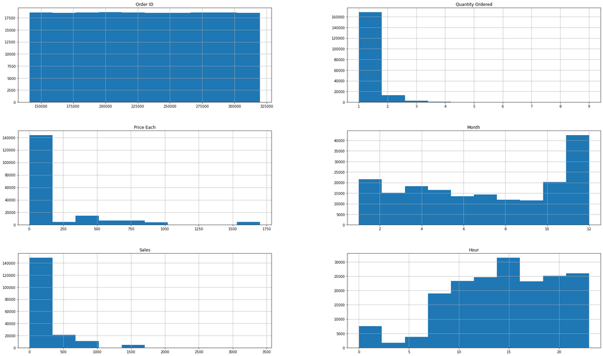

```python
# Use this, and more code cells, to explore your data. Don't forget to add
# Markdown cells to document your observations and findings.

df.hist(figsize = (30,18));
```

using plotting.scatter_matrix() function to draw Histogramsfor each column

and scatter plotting between numerical columns

and use figsize(,) parameter to show it obviously

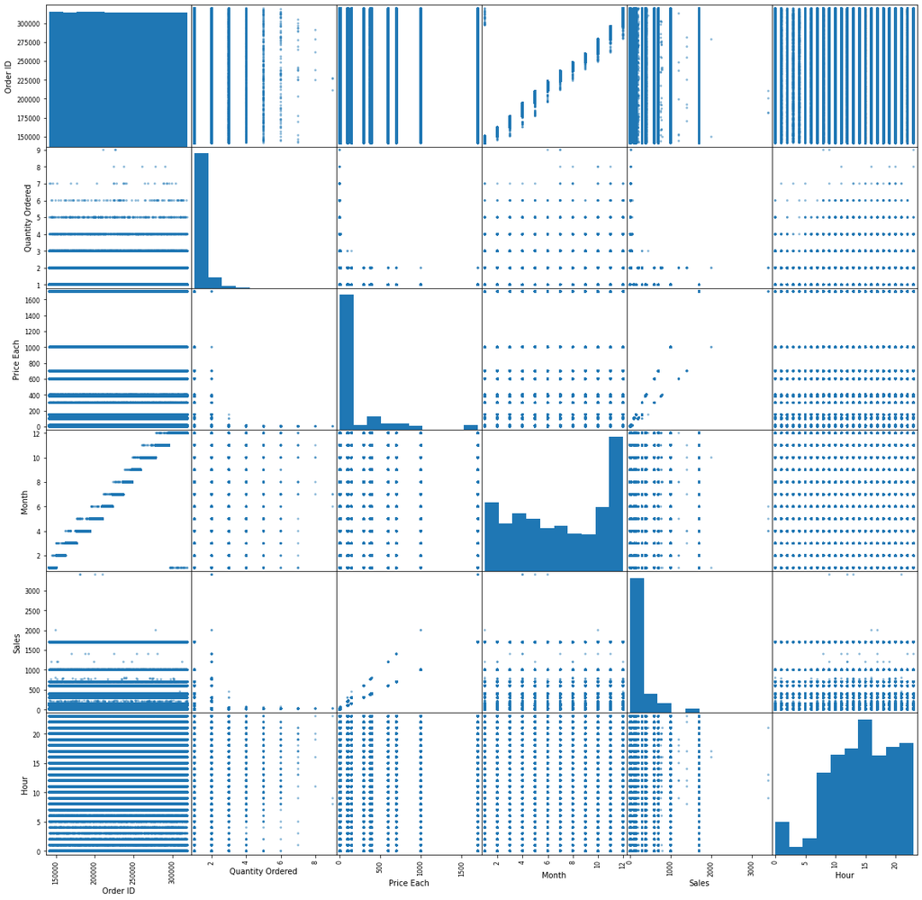

```python
pd.plotting.scatter_matrix(df, figsize = (20,20));
```

```python
df.info()
```

```
<class 'pandas.core.frame.DataFrame'>
RangeIndex: 185686 entries, 0 to 185685
Data columns (total 10 columns):
 #   Column            Non-Null Count   Dtype
---  ------            --------------   -----
 0   Order ID          185686 non-null  int64
 1   Product           185686 non-null  object
 2   Quantity Ordered  185686 non-null  int64
 3   Price Each        185686 non-null  float64
 4   Order Date        185686 non-null  object
 5   Purchase Address  185686 non-null  object
 6   Month             185686 non-null  int64
 7   Sales             185686 non-null  float64
 8   City              185686 non-null  object
 9   Hour              185686 non-null  int64
dtypes: float64(2), int64(4), object(4)
memory usage: 14.2+ MB
```

```python
City_value_counts = df.City.value_counts()
City_value_counts
```

```
 San Francisco    44662
 Los Angeles      29564
 New York City    24847
 Boston           19901
 Atlanta          14863
 Dallas           14797
 Seattle          14713
 Portland         12449
 Austin            9890
Name: City, dtype: int64
```

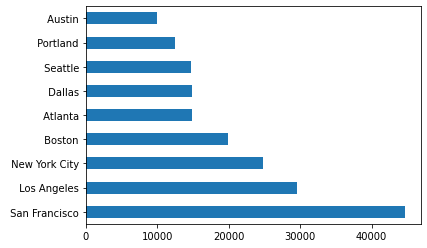

```python
df.City.value_counts().plot(kind='barh');
```

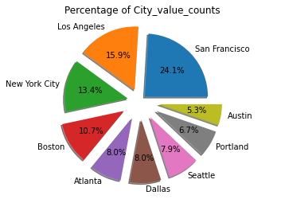

```python
# Creating a pie chart for cities
plt.pie (City_value_counts,
         labels = ['San Francisco','Los Angeles','New York City','Boston','Atlanta','Dallas','Seattle','Portland','Austin'],
         autopct = "%1.1f%%",
         shadow = True,
         explode = (0.1,0.2,0.2,0.3,0.3,0.3,0.3,0.3,0.3)
        )
plt.title ("Percentage of City_value_counts")
plt.axis ('equal') ;
```

```python
Product_value_counts = df.Product.value_counts()
Product_value_counts
```

```
USB-C Charging Cable          21859
Lightning Charging Cable      21610
AAA Batteries (4-pack)        20612
AA Batteries (4-pack)         20558
Wired Headphones              18849
Apple Airpods Headphones      15525
Bose SoundSport Headphones    13298
27in FHD Monitor               7498
iPhone                         6840
27in 4K Gaming Monitor         6225
34in Ultrawide Monitor         6174
Google Phone                   5522
Flatscreen TV                  4794
Macbook Pro Laptop             4721
ThinkPad Laptop                4126
20in Monitor                   4098
Vareebadd Phone                2065
LG Washing Machine              666
LG Dryer                        646
Name: Product, dtype: int64
```

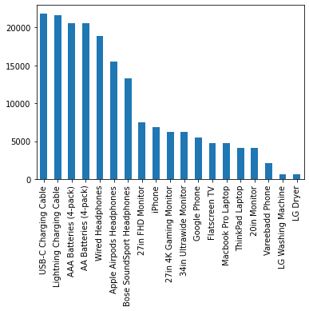

```python
df.Product.value_counts().plot(kind='bar');
#df.City.value_counts().plot(kind='barh');
```

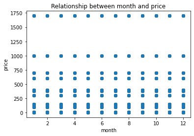

```python
plt.scatter(df.Month , df[['Price Each']])
plt.title ("Relationship between month and price")
plt.xlabel ("month")
plt.ylabel ("price")
```

```python
import os

directory_path = "./output/"
os.makedirs(directory_path, exist_ok=True)
```

```python
!jupyter nbconvert --to html --no-input sales.ipynb
```

```
[NbConvertApp] Converting notebook sales.ipynb to html
[NbConvertApp] Writing 967341 bytes to sales.html
```

```python
!jupyter nbconvert --to latex sales.ipynb
```

```
[NbConvertApp] Converting notebook sales.ipynb to latex
[NbConvertApp] Support files will be in sales_files\
[NbConvertApp] Making directory sales_files
[NbConvertApp] Making directory sales_files
[NbConvertApp] Making directory sales_files
[NbConvertApp] Making directory sales_files
[NbConvertApp] Making directory sales_files
[NbConvertApp] Making directory sales_files
[NbConvertApp] Writing 78958 bytes to sales.tex
```

```python
!jupyter nbconvert --to python sales.ipynb
```

```
[NbConvertApp] Converting notebook sales.ipynb to python
[NbConvertApp] Writing 9949 bytes to sales.py
```